# ML_project_1

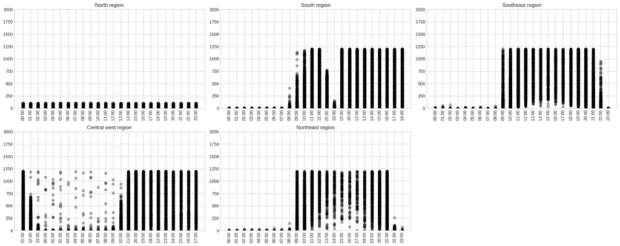

```python
plt.figure(figsize=(20, 8))
plt.subplot(2, 3, 1)
plt.scatter(north['Hora'],north['RADIACAO GLOBAL (Kj/m²)'],color = 'black',alpha=.3)
plt.ylim(0,2000)
plt.xticks(rotation=90)
plt.title('North region')

plt.subplot(2, 3, 2)
plt.scatter(south['Hora'],south['RADIACAO GLOBAL (Kj/m²)'],color = 'black',alpha=.3)
plt.ylim(0,2000)
plt.xticks(rotation=90)
plt.title('South region')

plt.subplot(2, 3, 3)
plt.scatter(southeast['Hora'],southeast['RADIACAO GLOBAL (Kj/m²)'],color = 'black',alpha=.3)
plt.ylim(0,2000)
plt.xticks(rotation=90)
plt.title('Southeast region')

plt.subplot(2, 3, 4)
plt.scatter(central_west['Hora'],central_west['RADIACAO GLOBAL (Kj/m²)'],color = 'black',alpha=.3)
plt.ylim(0,2000)
plt.xticks(rotation=90)
plt.title('Central west region')


plt.subplot(2, 3, 5)
plt.scatter(northeast['Hora'],northeast['RADIACAO GLOBAL (Kj/m²)'],color = 'black',alpha=.3)
plt.ylim(0,2000)
plt.title('Northeast region')
plt.tight_layout()
plt.xticks(rotation=90)
plt.show()
```

```python
data['region'] = data['region'].astype('category').cat.codes
data['region']
```

```
21       1
22       1
23       1
24       1
25       1
        ..
99995    4
99996    4
99997    4
99998    4
99999    4
Name: region, Length: 404560, dtype: int8
```

### In this code cell, I generated a sample dataset by randomly selecting approximately 10% of the original data. This approach significantly improves runtime efficiency and model training execution. The resulting dataset contains approximately 40,000 data points, facilitating smoother and faster model development.

```python
sample = data.sample(frac=0.1, random_state=42)
sample['region'].unique()
```

```
array([2, 0, 1, 3, 4], dtype=int8)
```

```python
from sklearn.decomposition import PCA
from sklearn.svm import SVC
from sklearn.pipeline import Pipeline


X = sample.drop(columns=['region','Data','state','station','station_code','Hora'])
y = sample['region']
#X_train,X_test,y_train,y_test = train_test_split(X,y, test_size = .99,random_state=42)
pca = PCA(n_components=2)
svc = SVC()
model = Pipeline([('pca', pca), ('svc', svc)])
model.fit(X, y)
```

```
Pipeline(steps=[('pca', PCA(n_components=2)), ('svc', SVC())])
```

```python
X_reduced = pca.transform(X).copy()
```

```python
x = sample[['PRECIPITAÇÃO TOTAL, HORÁRIO (mm)', 'TEMPERATURA DO PONTO DE ORVALHO (°C)']]
```

```python
x_train,x_test,Y_train,Y_test = train_test_split(X_reduced,y, test_size = .3,random_state=42)
from sklearn import svm
clf = svm.SVC(kernel = 'linear', C=1).fit(X_reduced,y)
y_pred = clf.predict(x_test)
C=1.0
h=.2
```

### In addition to the Support Vector Machine (SVM), I implemented a K-Nearest Neighbors (KNN) model and performed a comparative analysis of their accuracies. The SVM achieved an accuracy score of approximately 51%, while the KNN model yielded an accuracy of roughly 34%. Despite the SVM's higher accuracy score, both models exhibited subpar performance in predicting the values, indicating the need for further model refinement or feature engineering to enhance predictive accuracy.

```python
X_train,X_test,y_train,y_test = train_test_split(x,y, test_size = .5,random_state=42)
from sklearn.preprocessing import StandardScaler
scaler = StandardScaler()
scaler.fit(X_train)
X_train = scaler.transform(X_train)
X_test = scaler.transform(X_test)
```

```python
from sklearn.neighbors import KNeighborsClassifier
classifier = KNeighborsClassifier(n_neighbors=5)
classifier.fit(X_train, y_train)
k_pred = classifier.predict(X_test)
```

```python
from sklearn import metrics
print("SVM Accuracy:",metrics.accuracy_score(Y_test, y_pred))
print("KNN Accuracy:",metrics.accuracy_score(y_test, k_pred))
```

```
SVM Accuracy: 0.5176732306171212
KNN Accuracy: 0.34921890448882736
```

```python
x_min, x_max = X_train[:, 0].min() - 1, X_train[:, 0].max() + 1
y_min, y_max = X_train[:, 1].min() - 1,X_train[:, 1].max() + 1
xx, yy = np.meshgrid(np.arange(x_min, x_max, h),
                     np.arange(y_min, y_max, h))
```